# Time Series Homework: Chapter 2 Lesson 3

Eduardo Ramirez

## Data

```r
ind_prod <- rio::import("https://byuistats.github.io/timeseries/data/ind_prod_us.csv")
```

## Questions

### Question 1 - Context and Measurement (10 points)

The first part of any time series analysis is context. You cannot properly analyze data without knowing what the data is measuring. Without context, the most simple features of data can be obscure and inscrutable. This homework assignment will center around the series below.

Please research the time series. In the spaces below, give the data collection process, unit of analysis, and meaning of each observation for the series.

#### **Total US Industrial Production Index**

https://fred.stlouisfed.org/series/IPB50001N

**Answer**

The Federal Reserve’s monthly index of industrial production measures the real output of the U.S. industrial sector, which includes manufacturing, mining, and utilities, relative to a 2017 base of 100. The data is reported monthly in index form (not seasonally adjusted) and tracks changes in production activity over time, capturing fluctuations in economic performance. Each observation reflects the current level of industrial output compared to the base year, indicating growth or contraction in these sectors.

### Question 2 - Total US Industrial Production: Correlogram (20 points)

##### a) Please plot a correlogram of the US Industrial Production Index

**Answer**

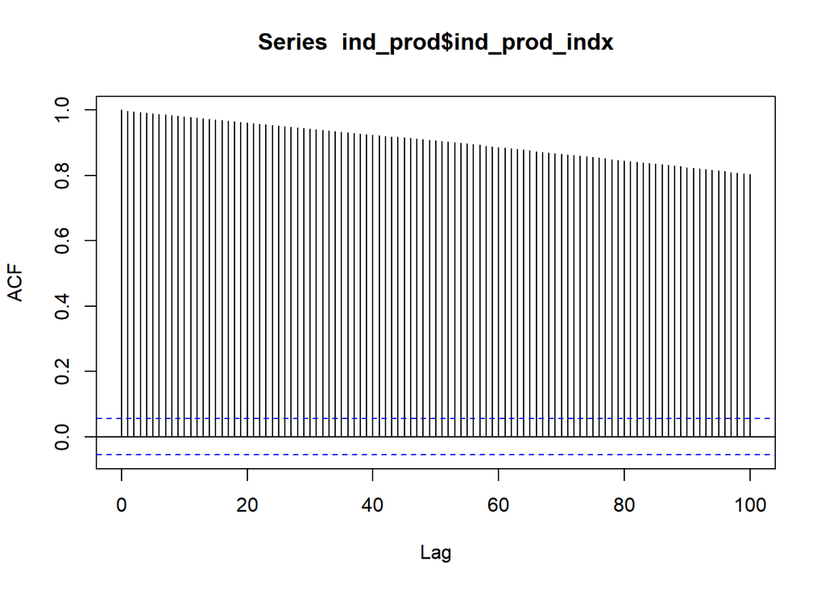

```r
acf(ind_prod$ind_prod_indx, plot=TRUE, type = "correlation", lag.max = 100)
```

```r
# correlogram table .head(10)
acf_values <- acf(ind_prod$ind_prod_indx, plot = FALSE, type = "correlation", lag.max = 100)
acf_table <- data.frame(Lag = acf_values$lag[1:10], ACF = acf_values$acf[1:10])

acf_table
```

```
   Lag       ACF
1    0 1.0000000
2    1 0.9977744
3    2 0.9958954
4    3 0.9940528
5    4 0.9921186
6    5 0.9902334
7    6 0.9883675
8    7 0.9863674
9    8 0.9843885
10   9 0.9825565
```

##### b) Please identify evidence of any trend or seasonal component using the correlogram. Please justify your findings.

**Answer**

Based on the correlogram of the US Industrial Production Index, there is evidence of a trend due to the slow decline in autocorrelation values across many lags, indicating persistent relationships over time. The high autocorrelation values gradually decrease, which is typical of a trending series. However, there is no clear evidence of a seasonal pattern, as the autocorrelation function (ACF) does not show repeating spikes at regular intervals.

### Question 3 - Total US Industrial Production: Decomposition (10 points)

##### a) Please plot a decomposition of the US Industrial Production Index series. Include the original series, trend, seasonal variation, and random component.

**Answer**

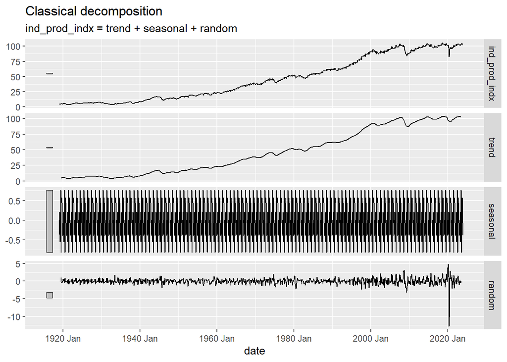

```r
ind_prod$date <- lubridate::mdy(ind_prod$date)
ind_prod$date <- yearmonth(ind_prod$date)
ind_prod$ind_prod_indx <- as.numeric(ind_prod$ind_prod_indx)

ind_tsbl <- as_tsibble(ind_prod, key = NULL, index = date, regular = TRUE)
# interval(ind_tsbl)
# has_gaps(ind_tsbl)

ind_decom_add <- ind_tsbl |>
  model(feasts::classical_decomposition(ind_prod_indx,
          type = "add"))  |>
  components()
autoplot(ind_decom_add)
```

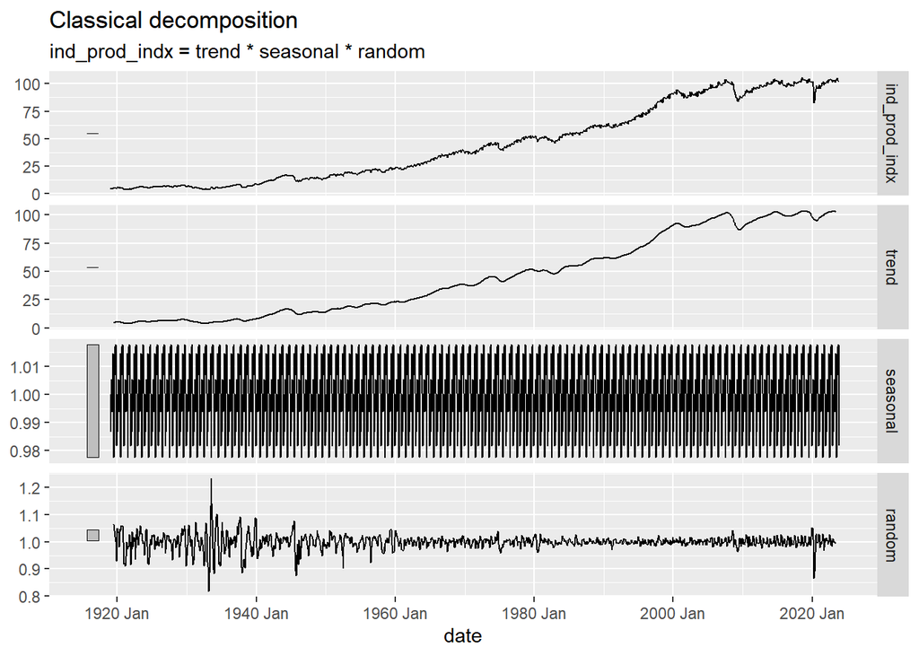

```r
ind_decom_mult <- ind_tsbl |>
  model(feasts::classical_decomposition(ind_prod_indx,
          type = "mult"))  |>
  components()
autoplot(ind_decom_mult)
```

##### b) Justify your choice of decomposition model (additive vs multiplicative)

**Answer**

The time series data is increasing over time, so based on what I have learned so far, we need to use the Multiplicative decomposition model. The seasonally adjusted X needs to account for seasonalities within the year and the overall average over time, so the seasonally adjusted X should do a good job of portraying the trend if there is one. The trend is rising over time, so we have a trend. The variation in the seasonal component between the additive decomposition is larger than the multiplicative decomposition, which we can see in the small bar to the left of the plot. Thus, the multiplicative decomposition does a better job of capturing the seasonal component. It is the same case for the other three components. So, the multiplicative model does a better job of capturing the trend, seasonal, and random components.  
The random component is noticeable because the multiplicative model has a range between 0.8 and 1.25 and, for the most part, stays between the random values of 0.95 and 1.05, so this model does a great job of identifying the ups and downs in this time series. The higher random components in the multiplicative decomposition can be linked to major world events and economic events, like major U.S. and/or world wars, the financial crisis of 2008, and COVID.

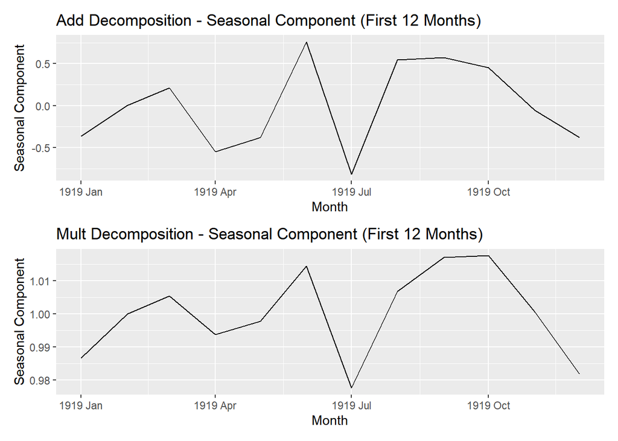

```r
# Filter to retain only the first 12 months of the seasonal component
ind_decom_add_12_seasonal <- ind_decom_add |> filter(row_number() <= 12) |> select(date, seasonal)
ind_decom_mult_12_seasonal <- ind_decom_mult |> filter(row_number() <= 12) |> select(date, seasonal)
# Plot additive seasonal component with only the first 12 months
plot_add_seasonal_12 <- ggplot(ind_decom_add_12_seasonal, aes(x = date, y = seasonal)) +
  geom_line() +
  ggtitle("Add Decomposition - Seasonal Component (First 12 Months)") +
  ylab("Seasonal Component") +
  xlab("Month")
# Plot multiplicative seasonal component with only the first 12 months
plot_mult_seasonal_12 <- ggplot(ind_decom_mult_12_seasonal, aes(x = date, y = seasonal)) +
  geom_line() +
  ggtitle("Mult Decomposition - Seasonal Component (First 12 Months)") +
  ylab("Seasonal Component") +
  xlab("Month")

# Combine both plots: Add on top, Multi on bottom
plot_add_seasonal_12 / plot_mult_seasonal_12
```

### Question 4 - Total US Industrial Production: Stationary Series (20 points)

##### a) Please plot a correlogram of the random component of the US Industrial Production Index

**Answer**

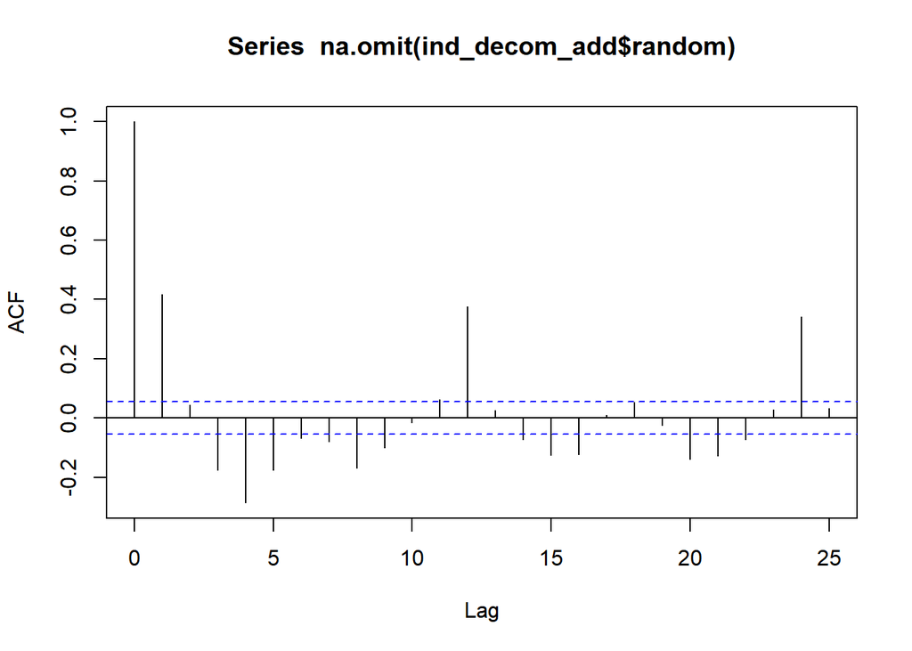

```r
acf(ind_decom_add$random |> na.omit(), plot=TRUE, type = "correlation", lag.max = 25)
```

##### b) Please interpret the correlogram of the random component of the US Industrial Production Index. Include descriptions of the statistical and practical significance of the results. Be careful to justify the cases when a statistically significant correlation is not practically significant.

**Answer**

The correlogram of the random component of the US Industrial Production Index indicates some statistically significant autocorrelations at certain lags, but these may not hold practical significance, as the random component should ideally exhibit minimal pattern. Although the presence of statistically significant correlations could suggest non-random influences, it is important to carefully assess whether these correlations correspond to meaningful economic fluctuations or are simply due to noise. Correlation doesn’t always equal causation so I just need to clarify with Brother Moncayo on how to properly answer this question.

### Question 5 - US Industrial Production Index: Introspection (20 points)

##### a) Why is it important to remove trend and seasonal variation before plotting and analyzing correlograms?

**Answer**

Removing trend and seasonal variation is essential to reveal the true autocorrelation structure of the time series, as trends and seasonal patterns can introduce misleadingly high or low correlations at various lags. By eliminating these components, the correlogram becomes a more accurate tool for identifying short-term relationships within the data. This step is crucial for meeting the stationarity assumption needed for reliable time series analysis.

##### b) Please speculate on the importance of autocorrelation analysis of the random component of time series data on its modeling and investigation?

**Answer**

Analyzing the autocorrelation of the random component helps to understand the underlying fluctuations and irregularities in the time series, highlighting the small-scale dynamics that may not be apparent from the main trend or seasonal patterns. This analysis can reveal subtle patterns or dependencies within the residuals, indicating if there are any remaining structures, such as minor trends or cyclical behavior, that could impact the model’s accuracy. It provides deeper insights into the data’s behavior, aiding in refining the model and ensuring it adequately captures all significant features.

### Rubric

[output not shown]

Back to top